# EasyVisa

Context

Business communities in the United States are facing high demand for human resources, but one of the constant challenges is identifying and attracting the right talent, which is perhaps the most important element in remaining competitive. Companies in the United States look for hard-working, talented, and qualified individuals both locally as well as abroad.

The Immigration and Nationality Act (INA) of the US permits foreign workers to come to the United States to work on either a temporary or permanent basis. The act also protects US workers against adverse impacts on their wages or working conditions by ensuring US employers' compliance with statutory requirements when they hire foreign workers to fill workforce shortages. The immigration programs are administered by the Office of Foreign Labor Certification (OFLC).

OFLC processes job certification applications for employers seeking to bring foreign workers into the United States and grants certifications in those cases where employers can demonstrate that there are not sufficient US workers available to perform the work at wages that meet or exceed the wage paid for the occupation in the area of intended employment.

# Objective

In FY 2016, the OFLC processed 775,979 employer applications for 1,699,957 positions for temporary and permanent labor certifications. This was a nine percent increase in the overall number of processed applications from the previous year. The process of reviewing every case is becoming a tedious task as the number of applicants is increasing every year.

The increasing number of applicants every year calls for a Machine Learning based solution that can help shortlist candidates with higher chances of VISA approval. OFLC has hired the firm EasyVisa for data-driven solutions. You as a data scientist at EasyVisa have to analyze the data provided and, with the help of a classification model:

Facilitate the process of visa approvals. Recommend a suitable profile for the applicants for whom the visa should be certified or denied based on the drivers that significantly influence the case status.

## Data Description

The data contains the different attributes of the employee and the employer. The detailed data dictionary is given below.

- case_id: ID of each visa application
- continent: Information of continent the employee
- education_of_employee: Information of education of the employee
- has_job_experience: Does the employee have any job experience? Y= Yes; N = No
- requires_job_training: Does the employee require any job training? Y = Yes; N = No
- no_of_employees: Number of employees in the employer's company
- yr_of_estab: Year in which the employer's company was established
- region_of_employment: Information of foreign worker's intended region of employment in the US.
- prevailing_wage: Average wage paid to similarly employed workers in a specific occupation in the area of intended employment. The purpose of the prevailing wage is to ensure that the foreign worker is not underpaid compared to other workers offering the same or similar service in the same area of employment.
- unit_of_wage: Unit of prevailing wage. Values include Hourly, Weekly, Monthly, and Yearly.
- full_time_position: Is the position of work full-time? Y = Full-Time Position; N = Part-Time Position
- case_status: Flag indicating if the Visa was certified or denied

## EDA Questions:

1. Those with higher education may want to travel abroad for a well-paid job. Does education play a role in Visa certification?
2. How does the visa status vary across different continents?
3. Experienced professionals might look abroad for opportunities to improve their lifestyles and career development. Does work experience influence visa status?
4. In the United States, employees are paid at different intervals. Which pay unit is most likely to be certified for a visa?
5. The US government has established a prevailing wage to protect local talent and foreign workers. How does the visa status change with the prevailing wage? Note: These are a few questions to help guide you in performing EDA. EDA has to be done beyond this set of questions to obtain the maximum point in the corresponding rubric section.

Importing necessary libraries

```python
# Install necessary packages
!apt-get install -y graphviz
!pip install graphviz
```

```
Reading package lists... Done
Building dependency tree... Done
Reading state information... Done
graphviz is already the newest version (2.42.2-6ubuntu0.1).
0 upgraded, 0 newly installed, 0 to remove and 49 not upgraded.
```

```python
import numpy as np
import pandas as pd
# libaries to help with data visualization
import matplotlib.pyplot as plt
import seaborn as sns

from sklearn.model_selection import train_test_split
from sklearn.tree import DecisionTreeClassifier
#import pydotplus as pydot
from sklearn import tree
import os
from IPython.display import Image
import graphviz
from sklearn import metrics
from sklearn.metrics import confusion_matrix, classification_report
from sklearn.metrics import accuracy_score,precision_score,recall_score,f1_score, roc_auc_score
from sklearn.ensemble import BaggingClassifier
from sklearn.ensemble import AdaBoostClassifier
from sklearn.ensemble import GradientBoostingClassifier
from sklearn.ensemble import RandomForestClassifier
from xgboost import XGBClassifier
from sklearn.metrics import accuracy_score,precision_score,recall_score,f1_score, roc_auc_score

from sklearn.model_selection import GridSearchCV, RandomizedSearchCV
from sklearn.ensemble import (BaggingClassifier,RandomForestClassifier,
                              GradientBoostingClassifier, AdaBoostClassifier, StackingClassifier)
```

```python
from google.colab import drive
drive.mount('/content/drive')
```

# Data Overview

```python
data = pd.read_csv("/content/drive/MyDrive/Python/Dataset/EasyVisa.csv")
```

```python
df = data.copy() # copying data to another varaible to preserve original data
```

```python
df.head()
```

|  | case_id | continent | education_of_employee | has_job_experience | requires_job_training | no_of_employees | yr_of_estab | region_of_employment | prevailing_wage | unit_of_wage | full_time_position | case_status |
| --- | --- | --- | --- | --- | --- | --- | --- | --- | --- | --- | --- | --- |
| 0 | EZYV01 | Asia | High School | N | N | 14513 | 2007 | West | 592.2029 | Hour | Y | Denied |
| 1 | EZYV02 | Asia | Master's | Y | N | 2412 | 2002 | Northeast | 83425.6500 | Year | Y | Certified |
| 2 | EZYV03 | Asia | Bachelor's | N | Y | 44444 | 2008 | West | 122996.8600 | Year | Y | Denied |
| 3 | EZYV04 | Asia | Bachelor's | N | N | 98 | 1897 | West | 83434.0300 | Year | Y | Denied |
| 4 | EZYV05 | Africa | Master's | Y | N | 1082 | 2005 | South | 149907.3900 | Year | Y | Certified |

```python
df.tail()
```

|  | case_id | continent | education_of_employee | has_job_experience | requires_job_training | no_of_employees | yr_of_estab | region_of_employment | prevailing_wage | unit_of_wage | full_time_position | case_status |
| --- | --- | --- | --- | --- | --- | --- | --- | --- | --- | --- | --- | --- |
| 25475 | EZYV25476 | Asia | Bachelor's | Y | Y | 2601 | 2008 | South | 77092.57 | Year | Y | Certified |
| 25476 | EZYV25477 | Asia | High School | Y | N | 3274 | 2006 | Northeast | 279174.79 | Year | Y | Certified |
| 25477 | EZYV25478 | Asia | Master's | Y | N | 1121 | 1910 | South | 146298.85 | Year | N | Certified |
| 25478 | EZYV25479 | Asia | Master's | Y | Y | 1918 | 1887 | West | 86154.77 | Year | Y | Certified |
| 25479 | EZYV25480 | Asia | Bachelor's | Y | N | 3195 | 1960 | Midwest | 70876.91 | Year | Y | Certified |

```python
df.shape
```

```
(25480, 12)
```

### observation

- Dataset has 25480 rows and 12 columns

```python
df.info()
```

```
<class 'pandas.core.frame.DataFrame'>
RangeIndex: 25480 entries, 0 to 25479
Data columns (total 12 columns):
 #   Column                 Non-Null Count  Dtype
---  ------                 --------------  -----
 0   case_id                25480 non-null  object
 1   continent              25480 non-null  object
 2   education_of_employee  25480 non-null  object
 3   has_job_experience     25480 non-null  object
 4   requires_job_training  25480 non-null  object
 5   no_of_employees        25480 non-null  int64
 6   yr_of_estab            25480 non-null  int64
 7   region_of_employment   25480 non-null  object
 8   prevailing_wage        25480 non-null  float64
 9   unit_of_wage           25480 non-null  object
 10  full_time_position     25480 non-null  object
 11  case_status            25480 non-null  object
dtypes: float64(1), int64(2), object(9)
memory usage: 2.3+ MB
```

### Obervation

- 2 variable are integer data type
- 1 variable has float data type
- 9 variable are object data type

```python
df[df.duplicated()] # checking the duplicate values
```

|  | case_id | continent | education_of_employee | has_job_experience | requires_job_training | no_of_employees | yr_of_estab | region_of_employment | prevailing_wage | unit_of_wage | full_time_position | case_status |
| --- | --- | --- | --- | --- | --- | --- | --- | --- | --- | --- | --- | --- |

```python
df.isnull().sum() #checking the null value
```

|  | 0 |
| --- | --- |
| case_id | 0 |
| continent | 0 |
| education_of_employee | 0 |
| has_job_experience | 0 |
| requires_job_training | 0 |
| no_of_employees | 0 |
| yr_of_estab | 0 |
| region_of_employment | 0 |
| prevailing_wage | 0 |
| unit_of_wage | 0 |
| full_time_position | 0 |
| case_status | 0 |

**dtype:** int64

```python
df.describe()
```

|  | no_of_employees | yr_of_estab | prevailing_wage |
| --- | --- | --- | --- |
| count | 25480.000000 | 25480.000000 | 25480.000000 |
| mean | 5667.043210 | 1979.409929 | 74455.814592 |
| std | 22877.928848 | 42.366929 | 52815.942327 |
| min | -26.000000 | 1800.000000 | 2.136700 |
| 25% | 1022.000000 | 1976.000000 | 34015.480000 |
| 50% | 2109.000000 | 1997.000000 | 70308.210000 |
| 75% | 3504.000000 | 2005.000000 | 107735.512500 |
| max | 602069.000000 | 2016.000000 | 319210.270000 |

### Observation

As per the above observation min number of employees are -26. But it is not posible. Therefor we'll going to replace -26 by median.

## Data Preprocessing

```python
negative_employees = df[df['no_of_employees'] <= 0]
negative_employees.shape
```

```
(33, 12)
```

### Observation

- 33 entries are having negative value in column "no_of_employees"

```python
df.loc[df['no_of_employees'] <= 0, 'no_of_employees'] = np.nan # replacing the negative value by Nan
```

```python
nan_data = df[df['no_of_employees'].isna()]
nan_data.shape
```

```
(33, 12)
```

```python
nan_data.head()
```

|  | case_id | continent | education_of_employee | has_job_experience | requires_job_training | no_of_employees | yr_of_estab | region_of_employment | prevailing_wage | unit_of_wage | full_time_position | case_status |
| --- | --- | --- | --- | --- | --- | --- | --- | --- | --- | --- | --- | --- |
| 245 | EZYV246 | Europe | Master's | N | N | NaN | 1980 | Northeast | 39452.99 | Year | Y | Certified |
| 378 | EZYV379 | Asia | Bachelor's | N | Y | NaN | 2011 | Northeast | 32506.14 | Year | Y | Denied |
| 832 | EZYV833 | South America | Master's | Y | N | NaN | 2002 | South | 129701.94 | Year | Y | Certified |
| 2918 | EZYV2919 | Asia | Master's | Y | N | NaN | 2005 | Midwest | 112799.46 | Year | Y | Certified |
| 6439 | EZYV6440 | Asia | Bachelor's | N | N | NaN | 2013 | South | 103.97 | Hour | Y | Denied |

```python
# Step 1: Coerce non-numeric values to NaN (if any are present)
df['no_of_employees'] = pd.to_numeric(df['no_of_employees'], errors='coerce')
```

```python
# Step 2: Fill any NaN values with the median (or 0 if desired)
median_value = df['no_of_employees'].median()
df['no_of_employees'] = df['no_of_employees'].fillna(median_value)
```

```python
df['no_of_employees'].isna().sum()
```

```
0
```

```python
df.describe()
```

|  | no_of_employees | yr_of_estab | prevailing_wage |
| --- | --- | --- | --- |
| count | 25480.000000 | 25480.000000 | 25480.000000 |
| mean | 5669.801531 | 1979.409929 | 74455.814592 |
| std | 22877.371642 | 42.366929 | 52815.942327 |
| min | 12.000000 | 1800.000000 | 2.136700 |
| 25% | 1028.000000 | 1976.000000 | 34015.480000 |
| 50% | 2112.000000 | 1997.000000 | 70308.210000 |
| 75% | 3504.000000 | 2005.000000 | 107735.512500 |
| max | 602069.000000 | 2016.000000 | 319210.270000 |

```python
df.nunique() # checking the unique values
```

|  | 0 |
| --- | --- |
| case_id | 25480 |
| continent | 6 |
| education_of_employee | 4 |
| has_job_experience | 2 |
| requires_job_training | 2 |
| no_of_employees | 7100 |
| yr_of_estab | 199 |
| region_of_employment | 5 |
| prevailing_wage | 25454 |
| unit_of_wage | 4 |
| full_time_position | 2 |
| case_status | 2 |

**dtype:** int64

### Observation

case_id has been randomly assign, which is not provide any material information for model building.

```python
df.drop(labels="case_id",axis=1, inplace = True)
```

```python
df.info()
```

```
<class 'pandas.core.frame.DataFrame'>
RangeIndex: 25480 entries, 0 to 25479
Data columns (total 11 columns):
 #   Column                 Non-Null Count  Dtype
---  ------                 --------------  -----
 0   continent              25480 non-null  object
 1   education_of_employee  25480 non-null  object
 2   has_job_experience     25480 non-null  object
 3   requires_job_training  25480 non-null  object
 4   no_of_employees        25480 non-null  float64
 5   yr_of_estab            25480 non-null  int64
 6   region_of_employment   25480 non-null  object
 7   prevailing_wage        25480 non-null  float64
 8   unit_of_wage           25480 non-null  object
 9   full_time_position     25480 non-null  object
 10  case_status            25480 non-null  object
dtypes: float64(2), int64(1), object(8)
memory usage: 2.1+ MB
```

```python
df.nunique()
```

|  | 0 |
| --- | --- |
| continent | 6 |
| education_of_employee | 4 |
| has_job_experience | 2 |
| requires_job_training | 2 |
| no_of_employees | 7100 |
| yr_of_estab | 199 |
| region_of_employment | 5 |
| prevailing_wage | 25454 |
| unit_of_wage | 4 |
| full_time_position | 2 |
| case_status | 2 |

**dtype:** int64

Converting all the object type into categories

```python
for col in df.columns[df.dtypes=='object']:
  df[col] = df[col].astype('category')
```

```python
df.info()
```

```
<class 'pandas.core.frame.DataFrame'>
RangeIndex: 25480 entries, 0 to 25479
Data columns (total 11 columns):
 #   Column                 Non-Null Count  Dtype
---  ------                 --------------  -----
 0   continent              25480 non-null  category
 1   education_of_employee  25480 non-null  category
 2   has_job_experience     25480 non-null  category
 3   requires_job_training  25480 non-null  category
 4   no_of_employees        25480 non-null  float64
 5   yr_of_estab            25480 non-null  int64
 6   region_of_employment   25480 non-null  category
 7   prevailing_wage        25480 non-null  float64
 8   unit_of_wage           25480 non-null  category
 9   full_time_position     25480 non-null  category
 10  case_status            25480 non-null  category
dtypes: category(8), float64(2), int64(1)
memory usage: 797.7 KB
```

# Exploratory Data Analysis

1. Those with higher education may want to travel abroad for a well-paid job. Does education play a role in Visa certification?
2. How does the visa status vary across different continents?
3. Experienced professionals might look abroad for opportunities to improve their lifestyles and career development. Does work experience influence visa status?
4. In the United States, employees are paid at different intervals. Which pay unit is most likely to be certified for a visa?
5. The US government has established a prevailing wage to protect local talent and foreign workers. How does the visa status change with the prevailing wage?

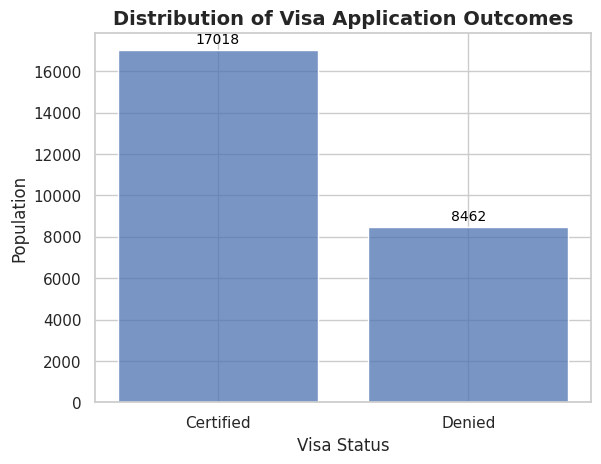

```python
# Set a modern theme for improved aesthetics
sns.set_theme(style="whitegrid")

# Create the plot with customized colors
ax = sns.histplot(data=df, x="case_status", palette={"Certified": "#4CAF50", "Denied": "#F44336"}, shrink=0.8)

# Enhance title and axis labels
plt.title("Distribution of Visa Application Outcomes", fontsize=14, fontweight='bold')
plt.xlabel("Visa Status", fontsize=12)
plt.ylabel("Population", fontsize=12)

# Add value annotations on each bar
for p in ax.patches:
    ax.annotate(f'{int(p.get_height())}',
                (p.get_x() + p.get_width() / 2., p.get_height()),
                ha='center', va='baseline', fontsize=10, color='black', xytext=(0, 5),
                textcoords='offset points')

# Show the plot
plt.show()
```

### Observation

17018 candidates are got visa out of 25480 candidates.

#### Q1. Those with higher education may want to travel abroad for a well-paid job. Does education play a role in Visa certification?

```python
df.groupby('education_of_employee')['case_status'].value_counts()
```

| education_of_employee | case_status | count |
| --- | --- | --- |
| Bachelor's | Certified | 6367 |
|  | Denied | 3867 |
| Doctorate | Certified | 1912 |
|  | Denied | 280 |
| High School | Denied | 2256 |
|  | Certified | 1164 |
| Master's | Certified | 7575 |
|  | Denied | 2059 |

**dtype:** int64

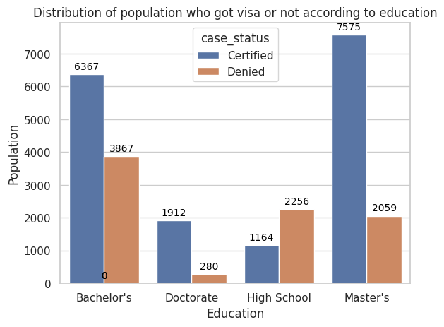

```python
ax = sns.countplot(data=df, x="education_of_employee",hue="case_status")
plt.title("Distribution of population who got visa or not according to education")
plt.xlabel("Education")
plt.ylabel("Population")

# Loop through the bars and display the value on top of each bar
for p in ax.patches:
    ax.annotate(f'{int(p.get_height())}',
                (p.get_x() + p.get_width() / 2., p.get_height()),
                ha='center', va='baseline', fontsize=10, color='black', xytext=(0, 5),
                textcoords='offset points')
plt.show();
```

### Observation

Education seems to play a role in visa certification success, as applicants with higher education, particularly those with a Master's degree, have the highest certification counts. This trend suggests that higher education may improve the likelihood of visa certification, possibly due to perceived qualifications or skills associated with advanced degrees.

#### Q2. How does the visa status vary across different continents?

```python
df.groupby('continent')['case_status'].value_counts()
```

| continent | case_status | count |
| --- | --- | --- |
| Africa | Certified | 397 |
|  | Denied | 154 |
| Asia | Certified | 11012 |
|  | Denied | 5849 |
| Europe | Certified | 2957 |
|  | Denied | 775 |
| North America | Certified | 2037 |
|  | Denied | 1255 |
| Oceania | Certified | 122 |
|  | Denied | 70 |
| South America | Certified | 493 |
|  | Denied | 359 |

**dtype:** int64

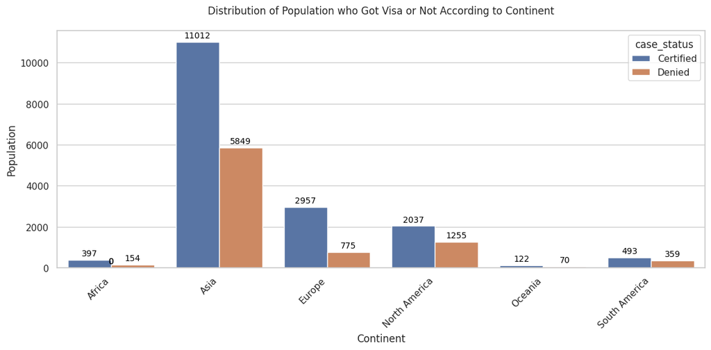

```python
# Set the figure size to be larger
plt.figure(figsize=(12, 6))

# Create the countplot
ax = sns.countplot(data=df, x="continent", hue="case_status")

# Customize the plot
plt.title("Distribution of Population who Got Visa or Not According to Continent", pad=20)
plt.xlabel("Continent")
plt.ylabel("Population")

# Rotate x-axis labels for better readability
plt.xticks(rotation=45, ha='right')

# Loop through the bars and display the value on top of each bar
for p in ax.patches:
    ax.annotate(f'{int(p.get_height())}',
                (p.get_x() + p.get_width() / 2., p.get_height()),
                ha='center', va='baseline', fontsize=10, color='black',
                xytext=(0, 5),
                textcoords='offset points')

# Adjust layout to prevent label cutoff
plt.tight_layout()

plt.show()
```

### Observation

#### Q3. Experienced professionals might look abroad for opportunities to improve their lifestyles and career development. Does work experience influence visa status?

```python
df.groupby('has_job_experience')['case_status'].value_counts()
```

| has_job_experience | case_status | count |
| --- | --- | --- |
| N | Certified | 5994 |
|  | Denied | 4684 |
| Y | Certified | 11024 |
|  | Denied | 3778 |

**dtype:** int64

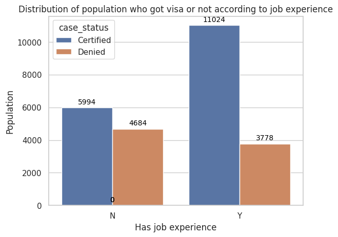

```python
ax = sns.countplot(data=df, x="has_job_experience",hue="case_status")
plt.title("Distribution of population who got visa or not according to job experience")
plt.xlabel("Has job experience")
plt.ylabel("Population")

# Loop through the bars and display the value on top of each bar
for p in ax.patches:
    ax.annotate(f'{int(p.get_height())}',
                (p.get_x() + p.get_width() / 2., p.get_height()),
                ha='center', va='baseline', fontsize=10, color='black', xytext=(0, 5),
                textcoords='offset points')
plt.show();
```

### Observation

The graph indicates that work experience influences visa status:

- Applicants with experience (Y) have more Certified visas (11,024) than Denied (3,778), showing a higher approval rate for experienced professionals.
- Applicants without experience (N) also have a significant number of visa approvals, with Certified (5,994) versus Denied (4,684). However, the approval rate is lower compared to experienced applicants.

#### Q4. In the United States, employees are paid at different intervals. Which pay unit is most likely to be certified for a visa?

```python
df.groupby('unit_of_wage')['case_status'].value_counts()
```

| unit_of_wage | case_status | count |
| --- | --- | --- |
| Hour | Denied | 1410 |
|  | Certified | 747 |
| Month | Certified | 55 |
|  | Denied | 34 |
| Week | Certified | 169 |
|  | Denied | 103 |
| Year | Certified | 16047 |
|  | Denied | 6915 |

**dtype:** int64

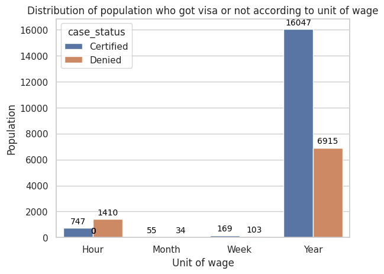

```python
ax = sns.countplot(data=df, x="unit_of_wage",hue="case_status")
plt.title("Distribution of population who got visa or not according to unit of wage")
plt.xlabel("Unit of wage")
plt.ylabel("Population")

# Loop through the bars and display the value on top of each bar
for p in ax.patches:
    ax.annotate(f'{int(p.get_height())}',
                (p.get_x() + p.get_width() / 2., p.get_height()),
                ha='center', va='baseline', fontsize=10, color='black', xytext=(0, 5),
                textcoords='offset points')
plt.show();
```

### Observation

The graph shows that the Yearly wage unit is most likely to be certified for a visa:

- Yearly pay has the highest number of Certified visas (16,047) compared to Denied (6,915), indicating a strong preference for yearly salaried positions in visa approvals.
- Other wage units like Hourly, Weekly, and Monthly have significantly lower visa certifications, with Hourly pay having 747 Certified and 1,410 Denied visas, indicating a higher denial rate for non-yearly wage types.

#### Q5. The US government has established a prevailing wage to protect local talent and foreign workers. How does the visa status change with the prevailing wage?

```python
df.groupby('unit_of_wage')['prevailing_wage'].mean()
```

| unit_of_wage | prevailing_wage |
| --- | --- |
| Hour | 414.570513 |
| Month | 87592.864045 |
| Week | 85606.820515 |
| Year | 81228.077133 |

**dtype:** float64

#### Observation

The data shows that the *unit_of_wage* 'Hour' is a per-day amount, whearas the other three *unit_of_wage* categories are an annual salary amount.

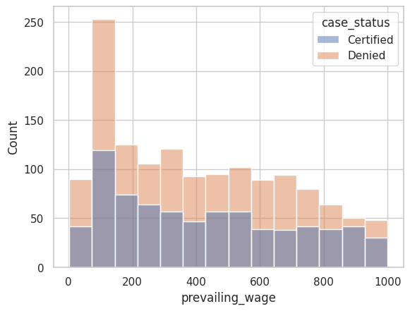

```python
#create a dataframe only of workers applying for jobs with a *unit_wage* of 'Hour'
df_hourly = df[df.unit_of_wage=='Hour']
#show a distribution of the *prevailing_wage* within this dataframe, along with the ratio of *case_status* within each bin
sns.histplot(data=df_hourly, x='prevailing_wage', hue='case_status')
plt.show()
```

```python
#create bins that categorize applicants by the per-day wage of the job he or she is applying for
bins = list(np.arange(0,1100,200))
#assign each applicant to a category
df_hourly['income_per_day'] = pd.cut(df_hourly['prevailing_wage'], bins)
df_hourly.groupby('income_per_day')['case_status'].value_counts()
```

| income_per_day | case_status | count |
| --- | --- | --- |
| (0, 200] | Denied | 448 |
|  | Certified | 219 |
| (200, 400] | Denied | 301 |
|  | Certified | 166 |
| (400, 600] | Denied | 274 |
|  | Certified | 144 |
| (600, 800] | Denied | 239 |
|  | Certified | 116 |
| (800, 1000] | Denied | 148 |
|  | Certified | 102 |

**dtype:** int64

[figure not shown]

```python
ax = sns.countplot(data=df_hourly, x="income_per_day",hue="case_status")
plt.title("Distribution of population who got visa or not according to full_time_position")
plt.xlabel("full_time_position")
plt.ylabel("Population")

# Loop through the bars and display the value on top of each bar
for p in ax.patches:
    ax.annotate(f'{int(p.get_height())}',
                (p.get_x() + p.get_width() / 2., p.get_height()),
                ha='center', va='baseline', fontsize=10, color='black', xytext=(0, 5),
                textcoords='offset points')
plt.show();
```

#### Observation

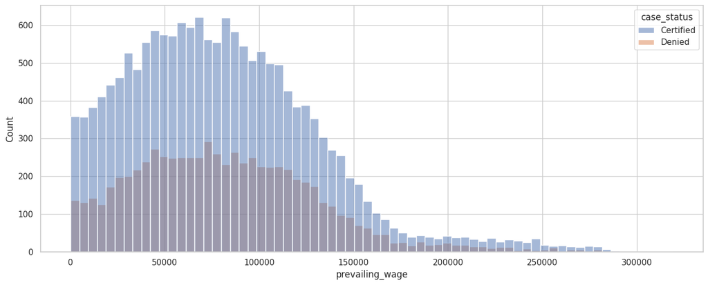

```python
#create a new dataframe of only those applicants applying for jobs with annual salaries (i.e., not 'Hour')
df_annual = df[df.unit_of_wage != "Hour"]
#show the distribution of annual salaries, along with ratio of *case_status* within each bin
plt.figure(figsize=(16,6))
sns.histplot(data=df_annual, x='prevailing_wage', hue='case_status')
plt.show()
```

#### Observation

- The distribution of wages is (as expected) right skewed, indicating a long-tail of jobs with annual salaries above 150,000 dollars.
- As the distribution above shows, the ratio of approved to denied applications remains approximately equivalent across the range of wages.

```python
#create bins to categorize a job by its annual salary, which indicates how well paying the job is
bins = [0,25000,50000,75000,100000,125000,np.inf]
names = ['$0-25k','$25k-50k','$50k-75k','$75k-100k','$100k-125k','$125k+']
#assign an applicant to a category
df_annual['income_per_year'] = pd.cut(df_annual['prevailing_wage'], bins, labels=names)
df_annual.groupby('income_per_year')['case_status'].value_counts()
```

| income_per_year | case_status | count |
| --- | --- | --- |
| $0-25k | Certified | 2090 |
|  | Denied | 761 |
| $25k-50k | Certified | 2839 |
|  | Denied | 1237 |
| $50k-75k | Certified | 3133 |
|  | Denied | 1372 |
| $75k-100k | Certified | 3014 |
|  | Denied | 1318 |
| $100k-125k | Certified | 2410 |
|  | Denied | 1138 |
| $125k+ | Certified | 2785 |
|  | Denied | 1226 |

**dtype:** int64

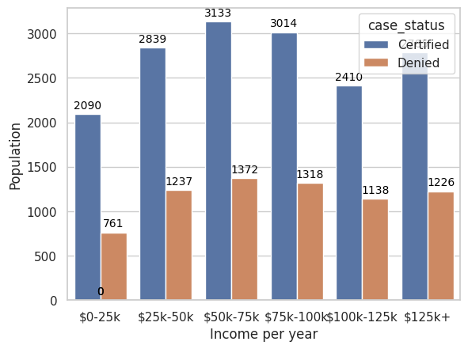

```python
ax = sns.countplot(data=df_annual, x="income_per_year",hue="case_status")
plt.xlabel("Income per year")
plt.ylabel("Population")

# Loop through the bars and display the value on top of each bar
for p in ax.patches:
    ax.annotate(f'{int(p.get_height())}',
                (p.get_x() + p.get_width() / 2., p.get_height()),
                ha='center', va='baseline', fontsize=10, color='black', xytext=(0, 5),
                textcoords='offset points')
plt.show();
```

#### Observation

- In support of the observation above, there does not appear to be a significant change in ratio of approved to denied applications as *income_per_year* increases. To the contrary, the ratio may actually decrease as this *prevailing_wage* increases.
- For applications for jobs with an *income_per_year* wage, the highest concentration of applications is for jobs with 50,000 to 75,000 dollars per year in salary.

```
continent    Africa   Asia  Europe  North America  Oceania  South America  \
case_status
All             551  16861    3732           3292      192            852
Certified       397  11012    2957           2037      122            493
Denied          154   5849     775           1255       70            359

continent      All
case_status
All          25480
Certified    17018
Denied        8462
------------------------------------------------------------------------------------------------------------------------
```

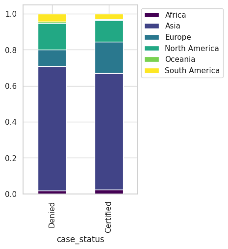

```
education_of_employee  Bachelor's  Doctorate  High School  Master's    All
case_status
All                         10234       2192         3420      9634  25480
Certified                    6367       1912         1164      7575  17018
Denied                       3867        280         2256      2059   8462
------------------------------------------------------------------------------------------------------------------------
```

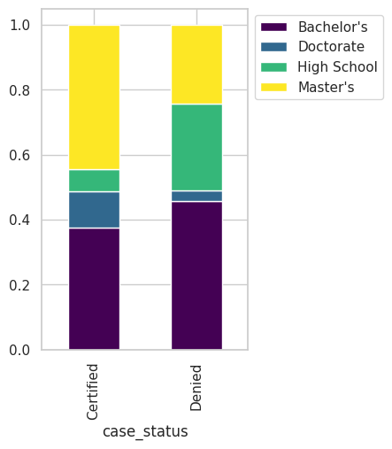

```
has_job_experience      N      Y    All
case_status
All                 10678  14802  25480
Certified            5994  11024  17018
Denied               4684   3778   8462
------------------------------------------------------------------------------------------------------------------------
```

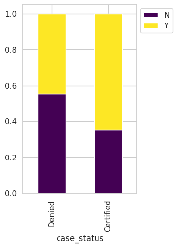

```
requires_job_training      N     Y    All
case_status
All                    22525  2955  25480
Certified              15012  2006  17018
Denied                  7513   949   8462
------------------------------------------------------------------------------------------------------------------------
```

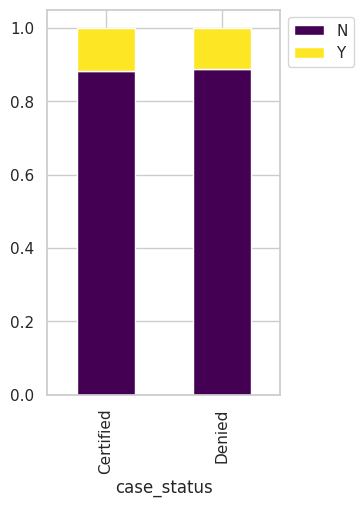

```
region_of_employment  Island  Midwest  Northeast  South  West    All
case_status
All                      375     4307       7195   7017  6586  25480
Certified                226     3253       4526   4913  4100  17018
Denied                   149     1054       2669   2104  2486   8462
------------------------------------------------------------------------------------------------------------------------
```

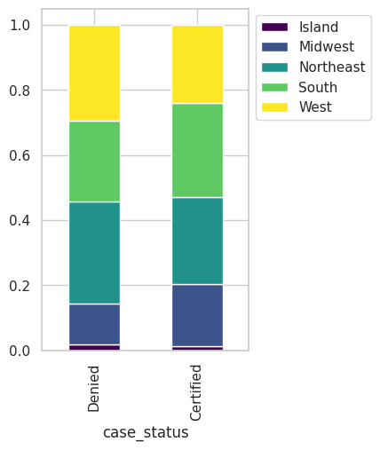

```
unit_of_wage  Hour  Month  Week   Year    All
case_status
All           2157     89   272  22962  25480
Certified      747     55   169  16047  17018
Denied        1410     34   103   6915   8462
------------------------------------------------------------------------------------------------------------------------
```

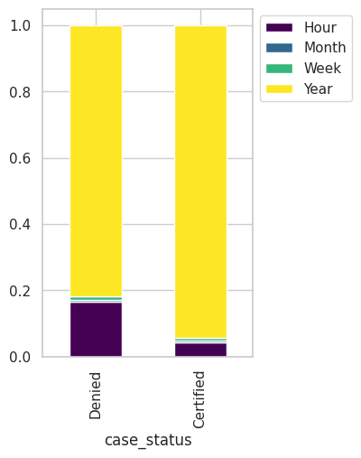

```
full_time_position     N      Y    All
case_status
All                 2707  22773  25480
Certified           1855  15163  17018
Denied               852   7610   8462
------------------------------------------------------------------------------------------------------------------------
```

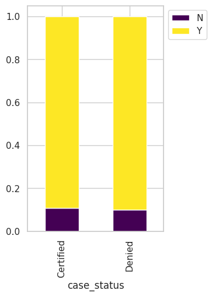

```
case_status  Certified  Denied    All
case_status
Denied               0    8462   8462
All              17018    8462  25480
Certified        17018       0  17018
------------------------------------------------------------------------------------------------------------------------
```

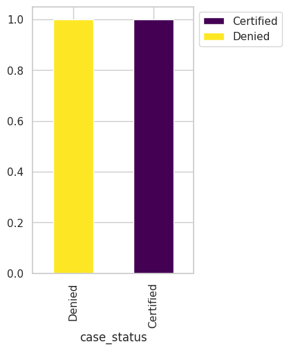

```python
def stacked_barplot(data, predictor, target):
    """
    Print the category counts and plot a stacked bar chart

    data: dataframe
    predictor: independent variable
    target: target variable
    """
    count = data[predictor].nunique()
    sorter = data[target].value_counts().index[-1]
    tab1 = pd.crosstab(data[predictor], data[target], margins=True).sort_values(
        by=sorter, ascending=False
    )
    print(tab1)
    print("-" * 120)
    tab = pd.crosstab(data[predictor], data[target], normalize="index").sort_values(
        by=sorter, ascending=False
    )
    tab.plot(kind="bar", stacked=True, figsize=(count + 1, 5), cmap='viridis')
    plt.legend(
        loc="lower left",
        frameon=False,
    )
    plt.legend(loc="upper left", bbox_to_anchor=(1, 1))
    plt.show()
#create a table and stacked barplot for each variable with a data type of category by case_status
cols_cat = df.select_dtypes(['category'])
for i in cols_cat.columns:
    stacked_barplot(df, "case_status", i)
```

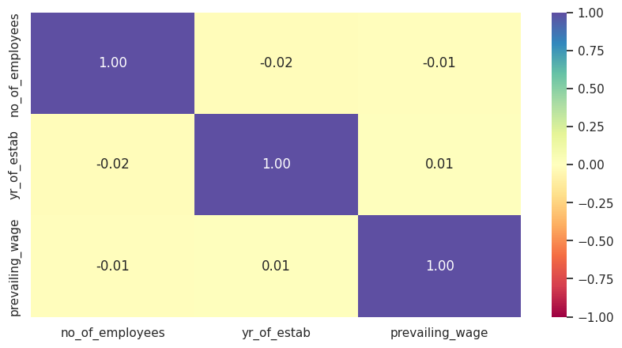

```python
cols_list = df.select_dtypes(include=np.number).columns.tolist()

# create the correlation matrix
plt.figure(figsize=(10, 5))
sns.heatmap(
    data[cols_list].corr(), annot=True, vmin=-1, vmax=1, fmt=".2f", cmap="Spectral"
)
plt.show()
```

### Observation

we cannot see any correlation between the numerical variables

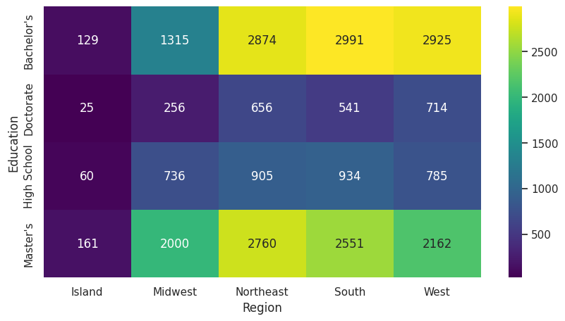

```python
plt.figure(figsize=(10, 5))
sns.heatmap(
    pd.crosstab(df["education_of_employee"], data["region_of_employment"]),
    annot=True,
    fmt="g",
    cmap="viridis",
)
plt.ylabel("Education")
plt.xlabel("Region")
plt.show()
```

#### Observation

- The requirement for the applicants who have passed high school is most in the South region, followed by Northeast region.
- The requirement for Bachelor's is mostly in South region, followed by West region.
- The requirement for Master's is most in Northeast region, followed by South region.
- The requirement for Doctorate's is mostly in West region, followed by Northeast region.

## Data Preprocessing

- Preparing data for modeling
- Splitting the data

#### Encoding Certified as 1 and Denied as 0, as the OFLC wants to identify those visa applicants who are predicted to be approved.

```python
df["case_status"] = df["case_status"].apply(lambda x: 1 if x == "Certified" else 0)
```

## Spliting the data

We will use 70% of data for training and 30% for testing.

```python
X= df.drop("case_status",axis=1)
Y=df.pop("case_status")
```

```python
#generate dummy variables for each categorical variable
X = pd.get_dummies(X, drop_first=True).astype(int)
```

```python
x_train, x_test, y_train, y_test = train_test_split(X,Y, test_size=0.30, random_state=1)
```

```python
#confirm the shape of both data sets and the ratio of classes is the same across both train and test datasets
print("Shape of Training set : ", x_train.shape)
print("Shape of test set : ", x_test.shape)
print(' ')
print("Percentage of classes in training set:")
print(y_train.value_counts(normalize=True))
print(' ')
print("Percentage of classes in test set:")
print(y_test.value_counts(normalize=True))
```

```
Shape of Training set :  (17836, 21)
Shape of test set :  (7644, 21)

Percentage of classes in training set:
case_status
1    0.663602
0    0.336398
Name: proportion, dtype: float64

Percentage of classes in test set:
case_status
1    0.677917
0    0.322083
Name: proportion, dtype: float64
```

#### Defining functions to provide metric scores (i.e., accuracy, recall, and precision) on the train and test datasets and to show the resulting confusion matrices.

```python
# defining a function to compute different metrics to check performance of a classification model built using sklearn
def model_performance_classification_sklearn(model, predictors, target):
    """
    Function to compute different metrics to check classification model performance

    model: classifier
    predictors: independent variables
    target: dependent variable
    """

    # predicting using the independent variables
    pred = model.predict(predictors)

    acc = accuracy_score(target, pred)  # to compute Accuracy
    recall = recall_score(target, pred)  # to compute Recall
    precision = precision_score(target, pred)  # to compute Precision
    f1 = f1_score(target, pred)  # to compute F1-score

    # creating a dataframe of metrics
    df_perf = pd.DataFrame(
        {
            "Accuracy": acc,
            "Recall": recall,
            "Precision": precision,
            "F1": f1,
        },
        index=[0],
    )

    return df_perf
```

```python
def confusion_matrix_sklearn(model, predictors, target):
    """
    To plot the confusion_matrix with percentages

    model: classifier
    predictors: independent variables
    target: dependent variable
    """
    y_pred = model.predict(predictors)
    cm = confusion_matrix(target, y_pred)
    labels = np.asarray(
        [
            ["{0:0.0f}".format(item) + "\n{0:.2%}".format(item / cm.flatten().sum())]
            for item in cm.flatten()
        ]
    ).reshape(2, 2)

    plt.figure(figsize=(6, 4))
    sns.heatmap(cm, annot=labels, fmt="")
    plt.ylabel("True label")
    plt.xlabel("Predicted label")
```

### Build Decision Tree Model

We will build our model using the DecisionTreeClassifier function. Using default 'gini' criteria to split.

```python
dTree = DecisionTreeClassifier(criterion='gini', random_state=1)
dTree.fit(x_train,y_train)
```

```
DecisionTreeClassifier(random_state=1)
```

```python
print(dTree.score(x_train,y_train))
print(dTree.score(x_test,y_test))
```

```
1.0
0.6628728414442701
```

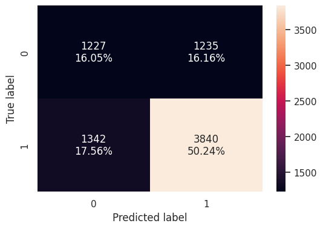

```python
#create a confusion matrix of the classifier's performance on the testing data
confusion_matrix_sklearn(dTree, x_test,y_test)
```

```python
decision_tree_model_train_pref = model_performance_classification_sklearn(dTree,x_train,y_train)
print("Training performance \n",decision_tree_model_train_pref)
```

```
Training performance
    Accuracy  Recall  Precision   F1
0       1.0     1.0        1.0  1.0
```

```python
decision_tree_model_test_pref = model_performance_classification_sklearn(dTree,x_test,y_test)
print("Testing performance \n",decision_tree_model_test_pref)
```

```
Testing performance
    Accuracy    Recall  Precision        F1
0  0.662873  0.741027    0.75665  0.748757
```

### Observation

The train score is 1 and test is 0.66. The decision tree is **overfit** the model

### Lets reduce the overfitting by purning.

```python
dTreeR = DecisionTreeClassifier(criterion='gini', max_depth=3, random_state=1)
dTreeR.fit(x_train,y_train)
print(dTreeR.score(x_train,y_train))
print(dTreeR.score(x_test,y_test))
```

```
0.7294236375869029
0.7333856619570905
```

Accuarcy of our modle is 73.33%

Decision Tree

```python
# Directly render the decision tree using graphviz
dot_data = tree.export_graphviz(dTreeR, out_file=None, feature_names=list(x_train), class_names=train_char_label, filled=True)
graph = graphviz.Source(dot_data)
graph.render("credit_tree")  # This will save the visualization to a file if needed
graph  # Display the decision tree in the notebook
```

[figure not shown]

```python
# importance of features in the tree building ( The importance of a feature is computed as the
#(normalized) total reduction of the criterion brought by that feature. It is also known as the Gini importance )

print (pd.DataFrame(dTreeR.feature_importances_, columns = ["Imp"], index = x_train.columns))
```

```
                                        Imp
no_of_employees                    0.000000
yr_of_estab                        0.000000
prevailing_wage                    0.093045
continent_Asia                     0.000000
continent_Europe                   0.000000
continent_North America            0.020818
continent_Oceania                  0.000000
continent_South America            0.000000
education_of_employee_Doctorate    0.000000
education_of_employee_High School  0.479732
education_of_employee_Master's     0.000000
has_job_experience_Y               0.289907
requires_job_training_Y            0.000000
region_of_employment_Midwest       0.000000
region_of_employment_Northeast     0.000000
region_of_employment_South         0.000000
region_of_employment_West          0.000000
unit_of_wage_Month                 0.000000
unit_of_wage_Week                  0.000000
unit_of_wage_Year                  0.116498
full_time_position_Y               0.000000
```

### Observation

The model’s predictions are primarily influenced by three features: education_of_employee_High School, has_job_experience_Y, and unit_of_wage_Year, with the education level being the most influential. Features like company size (no_of_employees), year of establishment (yr_of_estab), and most geographic variables do not impact the model’s predictions based on this particular dataset and decision tree. This analysis might suggest a need to focus more on education, job experience, and wage units in any decisions or further modeling.

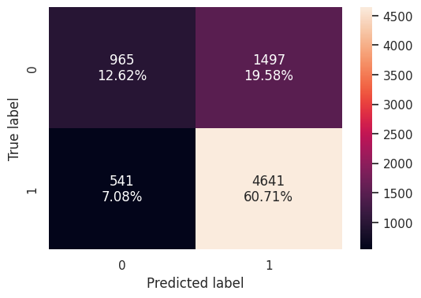

```python
#create a confusion matrix of the classifier's performance on the testing data
confusion_matrix_sklearn(dTreeR, x_test, y_test)
```

```python
dtreeR_model_train_perf=model_performance_classification_sklearn(dTreeR, x_train, y_train)
print("Training performance \n",dtreeR_model_train_perf)
```

```
Training performance
    Accuracy    Recall  Precision        F1
0  0.729424  0.898445   0.745827  0.815053
```

```python
dtreeR_model_test_perf=model_performance_classification_sklearn(dTreeR, x_test, y_test)
print("Testing performance \n",dtreeR_model_test_perf)
```

```
Testing performance
    Accuracy  Recall  Precision        F1
0  0.733386  0.8956   0.756109  0.819965
```

If we use pruning in Decision tree following is our output

- Accuracy = 0.733386
- Recall = 0.8956
- Precision = 0.756109
- F1 = 0.819965

### Bagging Classifier

```python
bgcl = BaggingClassifier(n_estimators=50,random_state=1)
#bgcl = BaggingClassifier(n_estimators=50,random_state=1)

bgcl = bgcl.fit(x_train, y_train)
```

```python
print(bgcl.score(x_train,y_train))
print(bgcl.score(x_test,y_test))
```

```
0.999607535321821
0.7244897959183674
```

Train score is 0.99 and test is 0.72. This model is overfitting the dataset

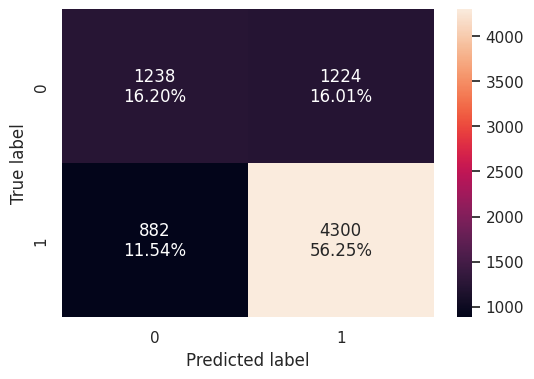

```python
#create a confusion matrix of the classifier's performance on the testing data
confusion_matrix_sklearn(bgcl, x_test, y_test)
```

```python
bagging_model_train_perf=model_performance_classification_sklearn(bgcl, x_train, y_train)
print("Training performance \n",bagging_model_train_perf)
```

```
Training performance
    Accuracy  Recall  Precision        F1
0  0.999608     1.0   0.999409  0.999704
```

```python
bagging_model_test_perf=model_performance_classification_sklearn(bgcl, x_test, y_test)
print("Testing performance \n",bagging_model_test_perf)
```

```
Testing performance
    Accuracy    Recall  Precision        F1
0   0.72449  0.829795   0.778421  0.803288
```

### Observation

Similar to the Decision Tree model with out pruning, this bagging classifer is overfit to the training dataset.

## AdaBoosting Classifier Model

```python
abcl = AdaBoostClassifier(n_estimators=10, random_state=1)
#abcl = AdaBoostClassifier( n_estimators=50,random_state=1)
abcl = abcl.fit(x_train, y_train)
```

```python
print(abcl.score(x_train,y_train))
print(abcl.score(x_test,y_test))
```

```
0.7368804664723032
0.7407116692830978
```

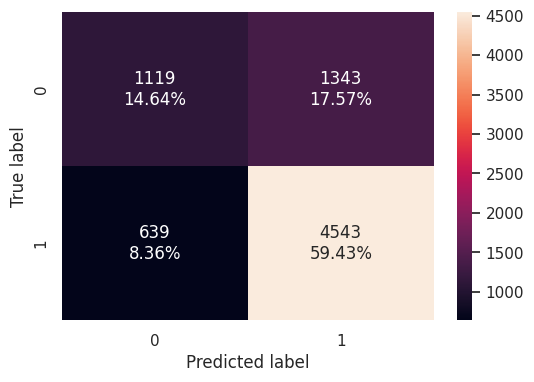

```python
#create a confusion matrix of the classifier's performance on the testing data
confusion_matrix_sklearn(abcl, x_test,y_test)
```

```python
ab_classifier_model_train_perf = model_performance_classification_sklearn(abcl,x_train,y_train)
print("Training performance \n",ab_classifier_model_train_perf)
```

```
Training performance
    Accuracy    Recall  Precision        F1
0   0.73688  0.877239   0.762167  0.815664
```

```python
ab_classifier_model_test_perf = model_performance_classification_sklearn(abcl,x_test,y_test)
print("Testing performance \n",ab_classifier_model_test_perf)
```

```
Testing performance
    Accuracy    Recall  Precision        F1
0  0.740712  0.876689   0.771831  0.820925
```

### Observation

- This AdaBoost classifer performs equally well on the training and testing datasets, indicating that the model is not overfit.
- Additionally, the model performs the best of any model yet (i.e., highest F1 score) on the testing data.

### Gradient Boosting Classifier

```python
gbcl = GradientBoostingClassifier(n_estimators = 50,random_state=1)
gbcl = gbcl.fit(x_train, y_train)
```

```python
print(gbcl.score(x_train,y_train))
print(gbcl.score(x_test,y_test))
```

```
0.7516819914779098
0.750261643118786
```

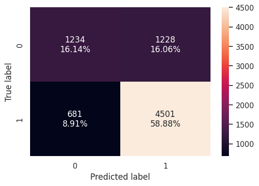

```python
#create a confusion matrix of the classifier's performance on the testing data
confusion_matrix_sklearn(gbcl, x_test,y_test)
```

```python
gbc_classifier_model_train_perf = model_performance_classification_sklearn(gbcl,x_train,y_train)
print("Training performance \n",gbc_classifier_model_train_perf)
```

```
Training performance
    Accuracy    Recall  Precision        F1
0  0.751682  0.875127    0.77827  0.823862
```

```python
gbc_classifier_model_test_perf = model_performance_classification_sklearn(gbcl,x_test,y_test)
print("Training performance \n",gbc_classifier_model_test_perf)
```

```
Training performance
    Accuracy    Recall  Precision        F1
0  0.750262  0.868584   0.785652  0.825039
```

### Observation

- This Gradient Boosting classifer performs equally well on the training and testing datasets, indicating that the model is not overfit.
- Additionally, this model performs even better than the AdaBoost model above.

### Random Forest Model

```python
rf =  RandomForestClassifier(n_estimators = 50, random_state=1,max_features=12)
rf.fit(x_train,y_train)
```

```
RandomForestClassifier(max_features=12, n_estimators=50, random_state=1)
```

```python
print(rf.score(x_train,y_train))
print(rf.score(x_test,y_test))
```

```
0.999495402556627
0.7243589743589743
```

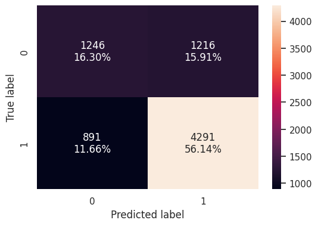

```python
#create a confusion matrix of the classifier's performance on the testing data
confusion_matrix_sklearn(rf,x_test,y_test)
```

```python
rf_model_train_perf=model_performance_classification_sklearn(rf,x_train,y_train)
print("Training performance \n",rf_model_train_perf)
```

```
Training performance
    Accuracy    Recall  Precision       F1
0  0.999495  0.999831   0.999409  0.99962
```

```python
rf_model_test_perf=model_performance_classification_sklearn(rf,x_test,y_test)
print("Testing performance \n",rf_model_test_perf)
```

```
Testing performance
    Accuracy    Recall  Precision        F1
0  0.724359  0.828059    0.77919  0.802881
```

### XGBoost Classifier

```
# This is formatted as code
```

```python
xgb = XGBClassifier(random_state=1,eval_metric='logloss')
xgb.fit(x_train,y_train)
```

```
XGBClassifier(base_score=None, booster=None, callbacks=None,
              colsample_bylevel=None, colsample_bynode=None,
              colsample_bytree=None, device=None, early_stopping_rounds=None,
              enable_categorical=False, eval_metric='logloss',
              feature_types=None, gamma=None, grow_policy=None,
              importance_type=None, interaction_constraints=None,
              learning_rate=None, max_bin=None, max_cat_threshold=None,
              max_cat_to_onehot=None, max_delta_step=None, max_depth=None,
              max_leaves=None, min_child_weight=None, missing=nan,
              monotone_constraints=None, multi_strategy=None, n_estimators=None,
              n_jobs=None, num_parallel_tree=None, random_state=1, ...)
```

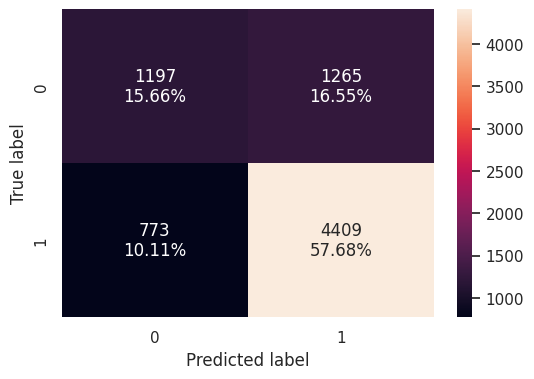

```python
#create a confusion matrix of the classifier's performance on the testing data
confusion_matrix_sklearn(xgb, x_test,y_test)
```

```python
print(xgb.score(x_train,y_train))
print(xgb.score(x_test,y_test))
```

```
0.8393137474770128
0.7333856619570905
```

```python
xgb_classifier_model_train_perf = model_performance_classification_sklearn(xgb,x_train,y_train)
print("Training performance \n",xgb_classifier_model_train_perf)
```

```
Training performance
    Accuracy   Recall  Precision        F1
0  0.839314  0.92827   0.844894  0.884622
```

```python
xgb_classifier_model_test_perf = model_performance_classification_sklearn(xgb,x_test,y_test)
print("Training performance \n",xgb_classifier_model_test_perf)
```

```
Training performance
    Accuracy   Recall  Precision       F1
0  0.733386  0.85083   0.777053  0.81227
```

### Observation

XGBoost Classifier is overfiting the model because the train score is 0.83 and test is 0.73

### Base models comparison

```python
# create a dataframe comparing the performance of the base models on the training data

models_train_comp_df = pd.concat(
    [decision_tree_model_train_pref.T,
     dtreeR_model_train_perf.T,
     bagging_model_train_perf.T,
     ab_classifier_model_train_perf.T,
     gbc_classifier_model_train_perf.T,
     rf_model_train_perf.T,
     xgb_classifier_model_train_perf.T],
    axis=1,
)
models_train_comp_df.columns = [
    "Decision Tree",
    "Decision Tree with pruning",
    "Bagging Classifier",
    "AdaBoost Classifier",
    "Gradient Boosting Classifier",
    "Random Forest",
    "XGBoost Classifier"]
print("Training performance comparison of base models:")
models_train_comp_df
```

```
Training performance comparison of base models:
```

|  | Decision Tree | Decision Tree with pruning | Bagging Classifier | AdaBoost Classifier | Gradient Boosting Classifier | Random Forest | XGBoost Classifier |
| --- | --- | --- | --- | --- | --- | --- | --- |
| Accuracy | 1.0 | 0.729424 | 0.999608 | 0.736880 | 0.751682 | 0.999495 | 0.839314 |
| Recall | 1.0 | 0.898445 | 1.000000 | 0.877239 | 0.875127 | 0.999831 | 0.928270 |
| Precision | 1.0 | 0.745827 | 0.999409 | 0.762167 | 0.778270 | 0.999409 | 0.844894 |
| F1 | 1.0 | 0.815053 | 0.999704 | 0.815664 | 0.823862 | 0.999620 | 0.884622 |

```python
# create a dataframe comparing the performance of the base models on the testing data

models_test_comp_df = pd.concat(
    [decision_tree_model_test_pref.T,
     dtreeR_model_test_perf.T,
     bagging_model_test_perf.T,
     ab_classifier_model_test_perf.T,
     gbc_classifier_model_test_perf.T,
     rf_model_test_perf.T,
     xgb_classifier_model_test_perf.T],
    axis=1,
)
models_test_comp_df.columns = [
    "Decision Tree",
    "Decision Tree with pruning",
    "Bagging Classifier",
    "AdaBoost Classifier",
    "Gradient Boosting Classifier",
    "Random Forest",
    "XGBoost Classifier"]
print("Testing performance comparison of base models:")
models_test_comp_df
```

```
Testing performance comparison of base models:
```

|  | Decision Tree | Decision Tree with pruning | Bagging Classifier | AdaBoost Classifier | Gradient Boosting Classifier | Random Forest | XGBoost Classifier |
| --- | --- | --- | --- | --- | --- | --- | --- |
| Accuracy | 0.662873 | 0.733386 | 0.724490 | 0.740712 | 0.750262 | 0.724359 | 0.733386 |
| Recall | 0.741027 | 0.895600 | 0.829795 | 0.876689 | 0.868584 | 0.828059 | 0.850830 |
| Precision | 0.756650 | 0.756109 | 0.778421 | 0.771831 | 0.785652 | 0.779190 | 0.777053 |
| F1 | 0.748757 | 0.819965 | 0.803288 | 0.820925 | 0.825039 | 0.802881 | 0.812270 |

## Hyperparameter tuning

##### Tuning Decision tree

```python
# Choose the type of classifier.
dtree_estimator = DecisionTreeClassifier(random_state=1)

# Grid of parameters to choose from
parameters = {'max_depth': np.arange(5,30,5),
              'min_samples_leaf': [3, 5, 7],
              'max_leaf_nodes' : [2, 4, 6],
              'min_impurity_decrease': [0.0001,0.001,0.01,0.1]
             }

# Type of scoring used to compare parameter combinations
scorer = metrics.make_scorer(metrics.f1_score)

# Run the grid search
grid_obj = GridSearchCV(dtree_estimator, parameters, scoring=scorer, cv=5)
grid_obj = grid_obj.fit(x_train, y_train)

# Set the clf to the best combination of parameters
dtree_estimator = grid_obj.best_estimator_

# Fit the best algorithm to the data.
dtree_estimator.fit(x_train, y_train)
```

```
DecisionTreeClassifier(max_depth=5, max_leaf_nodes=4,
                       min_impurity_decrease=0.0001, min_samples_leaf=3,
                       random_state=1)
```

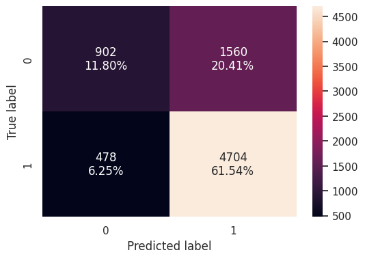

```python
#create a confusion matrix of the classifier's performance on the testing data
confusion_matrix_sklearn(dtree_estimator, x_test,y_test)
```

```python
dtree_estimator_model_train_perf=model_performance_classification_sklearn(dtree_estimator, x_train,y_train)
print("Training performance \n",dtree_estimator_model_train_perf)
```

```
Training performance
    Accuracy    Recall  Precision        F1
0  0.725275  0.908837   0.737893  0.814492
```

```python
dtree_estimator_model_test_perf=model_performance_classification_sklearn(dtree_estimator, x_test, y_test)
print("Testing performance \n",dtree_estimator_model_test_perf)
```

```
Testing performance
    Accuracy    Recall  Precision        F1
0  0.733386  0.907758   0.750958  0.821947
```

### Observation

- The Decision Tree model after tuning performs equally well on the training and testing datasets, indicating that the model is not overfit.
- Additionally, this model performs as well as two out of the three boosting models above on the test data.
- Both of these indicate this tuned model is a significant improvements over the base model.

**Tuning Bagging Classifier**

Hyperparameters available for bagging classifier include:

- base_estimator: The base estimator to fit on random subsets of the dataset. If None(default), then the base estimator is a decision tree.
- n_estimators: The number of trees in the forest, default = 100.
- max_features: The number of features to consider when looking for the best split.
- bootstrap: Whether bootstrap samples are used when building trees. If False, the entire dataset is used to build each tree, default=True.
- bootstrap_features: If it is true, then features are drawn with replacement. Default value is False.
- max_samples: If bootstrap is True, then the number of samples to draw from X to train each base estimator. If None (default), then draw N samples, where N is the number of observations in the train data.
- oob_score: Whether to use out-of-bag samples to estimate the generalization accuracy, default=False.

```python
# random search for bagging classifier
parameters = {'max_samples': [0.7,0.8,0.9,1],
              'max_features': [0.7,0.8,0.9,1],
              'n_estimators' : np.arange(50, 100, 10)
             }

#run the randomized search
rand_bag = RandomizedSearchCV(BaggingClassifier(random_state=1,bootstrap=True),
                              parameters, scoring = 'f1', cv = 5, random_state=1)
rand_bag = rand_bag.fit(x_train, y_train)

# Set the clf to the best combination of parameters
bag_tuned = rand_bag.best_estimator_

# Fit the best algorithm to the data
bag_tuned.fit(x_train, y_train)
```

```
BaggingClassifier(max_features=0.8, max_samples=0.8, n_estimators=70,
                  random_state=1)
```

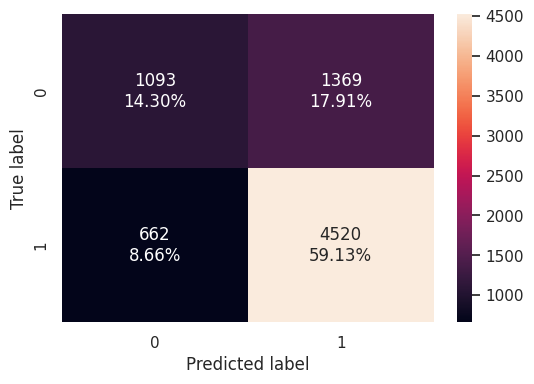

```python
#create a confusion matrix of the classifier's performance on the testing data
confusion_matrix_sklearn(bag_tuned, x_test,y_test)
```

```python
bagging_estimator_model_train_perf=model_performance_classification_sklearn(bag_tuned, x_train,y_train)
print("Training performance \n",bagging_estimator_model_train_perf)
```

```
Training performance
    Accuracy  Recall  Precision        F1
0  0.998935     1.0   0.998397  0.999198
```

```python
bagging_estimator_model_test_perf=model_performance_classification_sklearn(bag_tuned, x_test, y_test)
print("Testing performance \n",bagging_estimator_model_test_perf)
```

```
Testing performance
    Accuracy   Recall  Precision        F1
0  0.734301  0.87225   0.767533  0.816548
```

### Observation

- The Bagging Classifier after tuning performs far less well on the test data than on the training data, indicating that the model is still overfit.
- However, this model does perform better than the base model.

**Tuning Random Forest**

Hyperparameters for Random Forest include:

- n_estimators: The number of trees in the forest, default = 100.
- max_features: The number of features to consider when looking for the best split.
- class_weight: Weights associated with classes in the form {class_label: weight}.If not given, all classes are supposed to have weight one.
- For example: If the frequency of class 0 is 80% and the frequency of class 1 is 20% in the data, then class 0 will become the dominant class and the model will become biased toward the dominant classes. In this case, we can pass a dictionary {0:0.2,1:0.8} to the model to specify the weight of each class and the random forest will give more weightage to class 1.
- bootstrap: Whether bootstrap samples are used when building trees. If False, the entire dataset is used to build each tree, default=True.
- max_samples: If bootstrap is True, then the number of samples to draw from X to train each base estimator. If None (default), then draw N samples, where N is the number of observations in the train data.
- oob_score: Whether to use out-of-bag samples to estimate the generalization accuracy, default=False.
- Note: A lot of hyperparameters of Decision Trees are also available to tune Random Forest like max_depth, min_sample_split etc.

```python
# Choose the type of classifier.
rf_estimator = RandomForestClassifier(random_state=1)

# Grid of parameters to choose from
parameters = {"n_estimators": np.arange(10, 40, 10),
              "min_samples_leaf": np.arange(5, 10),
              "min_samples_split": [3, 5, 7],
              "max_features": ["sqrt", "log2"],
              "max_samples": np.arange(0.3, 0.7, 0.1),
}

# Run the randomized search
rand_rf = RandomizedSearchCV(rf_estimator, parameters, scoring='f1', cv=5, n_jobs=-1, random_state=1)
rand_rf = grid_obj.fit(x_train, y_train)

# Set the clf to the best combination of parameters
rf_estimator = rand_rf.best_estimator_

# Fit the best algorithm to the data.
rf_estimator.fit(x_train, y_train)
```

```
DecisionTreeClassifier(max_depth=5, max_leaf_nodes=4,
                       min_impurity_decrease=0.0001, min_samples_leaf=3,
                       random_state=1)
```

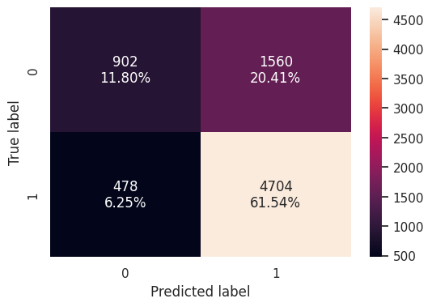

```python
#create a confusion matrix of the classifier's performance on the testing data
confusion_matrix_sklearn(rf_estimator, x_test,y_test)
```

```python
rf_estimator_model_train_perf=model_performance_classification_sklearn(rf_estimator, x_train,y_train)
print("Training performance \n",rf_estimator_model_train_perf)
```

```
Training performance
    Accuracy    Recall  Precision        F1
0  0.725275  0.908837   0.737893  0.814492
```

```python
rf_estimator_model_test_perf=model_performance_classification_sklearn(rf_estimator, x_test, y_test)
print("Testing performance \n",rf_estimator_model_test_perf)
```

```
Testing performance
    Accuracy    Recall  Precision        F1
0  0.733386  0.907758   0.750958  0.821947
```

### Observation

#### Tuning AdaBoost Classifier

Hyperparameters include:

- base_estimator: The base estimator from which the boosted ensemble is built. By default the base estimator is a decision tree with max_depth=1
- n_estimators: The maximum number of estimators at which boosting is terminated. Default value is 50.
- learning_rate: Learning rate shrinks the contribution of each classifier by learning_rate. There is a trade-off between learning_rate and n_estimators.

```python
# Choose the type of classifier.
abc_tuned = AdaBoostClassifier(random_state=1)

# Grid of parameters to choose from
parameters = {
    # Let's try different max_depth for the base estimator
    "estimator": [
        DecisionTreeClassifier(max_depth=1, random_state=1, class_weight='balanced'),
        DecisionTreeClassifier(max_depth=2, random_state=1, class_weight='balanced'),
        DecisionTreeClassifier(max_depth=3, random_state=1, class_weight='balanced')
    ],
    "n_estimators": np.arange(10, 110, 10),
    "learning_rate": np.arange(0.1, 2, 0.1)
}

# Type of scoring used to compare parameter combinations
acc_scorer = metrics.make_scorer(metrics.f1_score)

# Run the randomized search
rand_abc = RandomizedSearchCV(abc_tuned, parameters, scoring=acc_scorer, cv=5, n_jobs=-1, random_state=1)
rand_abc = rand_abc.fit(x_train, y_train)

# Set the clf to the best combination of parameters
abc_tuned = rand_abc.best_estimator_

# Fit the best algorithm to the data
abc_tuned.fit(x_train, y_train)
```

```
AdaBoostClassifier(estimator=DecisionTreeClassifier(class_weight='balanced',
                                                    max_depth=1,
                                                    random_state=1),
                   learning_rate=0.5, n_estimators=20, random_state=1)
```

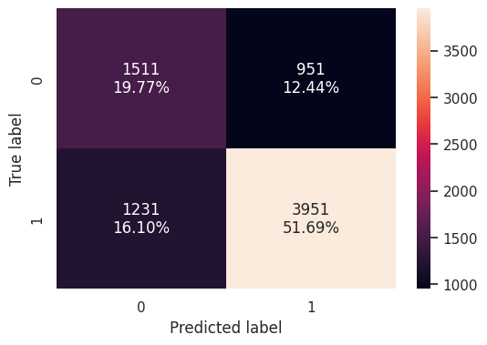

```python
#create a confusion matrix of the classifier's performance on the testing data
confusion_matrix_sklearn(abc_tuned, x_test,y_test)
```

```python
abc_tuned_model_train_perf=model_performance_classification_sklearn(abc_tuned, x_train,y_train)
print("Training performance \n",abc_tuned_model_train_perf)
```

```
Training performance
    Accuracy    Recall  Precision        F1
0  0.717425  0.759463   0.803881  0.781041
```

```python
abc_tuned_model_test_perf=model_performance_classification_sklearn(abc_tuned, x_test, y_test)
print("Testing performance \n",abc_tuned_model_test_perf)
```

```
Testing performance
    Accuracy    Recall  Precision        F1
0  0.714547  0.762447   0.805998  0.783618
```

### Observation

- The AdaBoost classifier after tuning performs equally well on the training and testing datasets, indicating that the model is not overfit.
- However, this model performs worse than the base model on both the train and test data.

#### Tuning GradientBoost Classifier

Most of the hyperparameters available match those of a random forest classifier.

- init: An estimator object that is used to compute the initial predictions. If ‘zero’, the initial raw predictions are set to zero. By default, a DummyEstimator predicting the classes priors is used.
- There is no class_weights parameter in gradient boosting.

```python
# Choose the type of classifier.
gb_tuned = GradientBoostingClassifier(random_state=1)

# Grid of parameters to choose from
parameters = {"n_estimators": [150,200,250,300],
              "subsample":[0.8,0.9,1],
              "max_features":[0.7,0.8,0.9,1],
              "learning_rate": np.arange(0.1, 0.4, 0.1)}

# Type of scoring used to compare parameter combinations
scorer = metrics.make_scorer(metrics.f1_score)

# Run the randomized search
rand_gb = RandomizedSearchCV(gb_tuned, parameters, scoring=scorer,cv=5, n_jobs=-1, random_state=1)
rand_gb = rand_gb.fit(x_train, y_train)

# Set the clf to the best combination of parameters
gb_tuned = rand_gb.best_estimator_

# Fit the best algorithm to the data.
gb_tuned.fit(x_train, y_train)
```

```
GradientBoostingClassifier(max_features=1, n_estimators=250, random_state=1,
                           subsample=1)
```

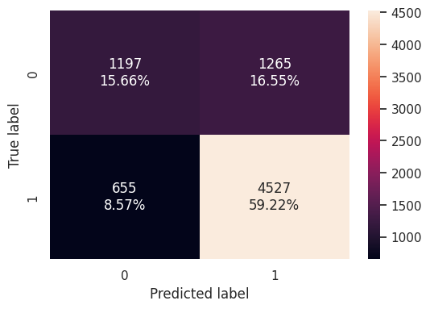

```python
#create a confusion matrix of the classifier's performance on the testing data
confusion_matrix_sklearn(gb_tuned, x_test,y_test)
```

```python
gb_tuned_model_train_perf=model_performance_classification_sklearn(rf_estimator, x_train,y_train)
print("Training performance \n",gb_tuned_model_train_perf)
```

```
Training performance
    Accuracy    Recall  Precision        F1
0  0.725275  0.908837   0.737893  0.814492
```

```python
gb_tuned_model_test_perf=model_performance_classification_sklearn(rf_estimator, x_test, y_test)
print("Testing performance \n",gb_tuned_model_test_perf)
```

```
Testing performance
    Accuracy    Recall  Precision        F1
0  0.733386  0.907758   0.750958  0.821947
```

### Observation

#### Tuning XGB Classifer

Important parameters include:

- scale_pos_weight:Control the balance of positive and negative weights, useful for unbalanced classes. It has range from 0 to $\infty$.
- subsample: Corresponds to the fraction of observations (the rows) to subsample at each step. By default it is set to 1 meaning that we use all rows.
- colsample_bytree: Corresponds to the fraction of features (the columns) to use.
- colsample_bylevel: The subsample ratio of columns for each level. Columns are subsampled from the set of columns chosen for the current tree.
- colsample_bynode: The subsample ratio of columns for each node (split). Columns are subsampled from the set of columns chosen for the current level.
- max_depth: is the maximum number of nodes allowed from the root to the farthest leaf of a tree.
- learning_rate/eta: Makes the model more robust by shrinking the weights on each step.
- gamma: A node is split only when the resulting split gives a positive reduction in the loss function. Gamma specifies the minimum loss reduction required to make a split.

```python
# Choose the type of classifier.
xgb_tuned = XGBClassifier(random_state=1, eval_metric='logloss')

# Grid of parameters to choose from
parameters = {"n_estimators": np.arange(10,100,20),
              "scale_pos_weight":[0,1,2,5],
              "subsample":[0.5,0.7,0.9,1],
              "learning_rate":[0.01,0.1,0.2,0.05],
              "gamma":[0,1,3],
              "colsample_bytree":[0.5,0.7,0.9,1],
              "colsample_bylevel":[0.5,0.7,0.9,1]}

# Type of scoring used to compare parameter combinations
scorer = metrics.make_scorer(metrics.f1_score)

# Run the randomized search
rand_xgb = RandomizedSearchCV(xgb_tuned, parameters, scoring=scorer,cv=5, n_jobs=-1, random_state=1)
rand_xgb = rand_xgb.fit(x_train, y_train)

# Set the clf to the best combination of parameters
xgb_tuned = rand_xgb.best_estimator_

# Fit the best algorithm to the data.
xgb_tuned.fit(x_train, y_train)
```

```
XGBClassifier(base_score=None, booster=None, callbacks=None,
              colsample_bylevel=0.9, colsample_bynode=None,
              colsample_bytree=0.5, device=None, early_stopping_rounds=None,
              enable_categorical=False, eval_metric='logloss',
              feature_types=None, gamma=0, grow_policy=None,
              importance_type=None, interaction_constraints=None,
              learning_rate=0.1, max_bin=None, max_cat_threshold=None,
              max_cat_to_onehot=None, max_delta_step=None, max_depth=None,
              max_leaves=None, min_child_weight=None, missing=nan,
              monotone_constraints=None, multi_strategy=None, n_estimators=70,
              n_jobs=None, num_parallel_tree=None, random_state=1, ...)
```

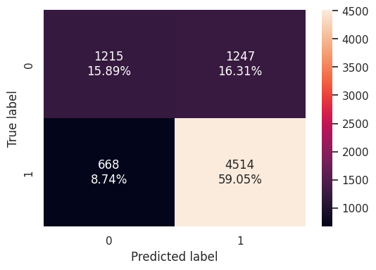

```python
confusion_matrix_sklearn(xgb_tuned, x_test,y_test)
```

```python
xgb_tuned_model_train_perf=model_performance_classification_sklearn(xgb_tuned, x_train,y_train)
print("Training performance \n",xgb_tuned_model_train_perf)
```

```
Training performance
    Accuracy    Recall  Precision        F1
0  0.769904  0.890081   0.789849  0.836975
```

```python
xgb_tuned_model_test_perf=model_performance_classification_sklearn(xgb_tuned, x_test, y_test)
print("Testing performance \n",xgb_tuned_model_test_perf)
```

```
Testing performance
    Accuracy    Recall  Precision        F1
0  0.749477  0.871092   0.783545  0.825002
```

### Observation

- The XGBoost classifier after tuning is less overfit than the base model, but performs equally well on the test data.
- This indicates a minor improvement over the base model.

### Tuned models comparison

```python
# create a dataframe comparing the performance of the tuned models on the training data

tuned_models_train_comp_df = pd.concat(
    [dtree_estimator_model_train_perf.T,
     bagging_estimator_model_train_perf.T,
     rf_estimator_model_train_perf.T,
     abc_tuned_model_train_perf.T,
     gb_tuned_model_train_perf.T,
     xgb_tuned_model_train_perf.T],
    axis=1,
)
tuned_models_train_comp_df.columns = [
    "Tuned Decision Tree",
    "Tuned Bagging Classifier",
    "Tuned Random Forest",
    "Tuned AdaBoost Classifier",
    "Tuned Gradient Boosting Classifier",
    "Tuned XGBoost Classifier"]
print("Training performance comparison of tuned models:")
tuned_models_train_comp_df
```

```
Training performance comparison of tuned models:
```

|  | Tuned Decision Tree | Tuned Bagging Classifier | Tuned Random Forest | Tuned AdaBoost Classifier | Tuned Gradient Boosting Classifier | Tuned XGBoost Classifier |
| --- | --- | --- | --- | --- | --- | --- |
| Accuracy | 0.725275 | 0.998935 | 0.725275 | 0.717425 | 0.725275 | 0.769904 |
| Recall | 0.908837 | 1.000000 | 0.908837 | 0.759463 | 0.908837 | 0.890081 |
| Precision | 0.737893 | 0.998397 | 0.737893 | 0.803881 | 0.737893 | 0.789849 |
| F1 | 0.814492 | 0.999198 | 0.814492 | 0.781041 | 0.814492 | 0.836975 |

```python
# create a dataframe comparing the performance of the tuned models on the testing data

tuned_models_test_comp_df = pd.concat(
    [dtree_estimator_model_test_perf.T,
     bagging_estimator_model_test_perf.T,
     rf_estimator_model_test_perf.T,
     abc_tuned_model_test_perf.T,
     gb_tuned_model_test_perf.T,
     xgb_tuned_model_test_perf.T],
    axis=1,
)
tuned_models_test_comp_df.columns = [
    "Tuned Decision Tree",
    "Tuned Bagging Classifier",
    "Tuned Random Forest",
    "Tuned AdaBoost Classifier",
    "Tuned Gradient Boosting Classifier",
    "Tuned XGBoost Classifier"]
print("Testing performance comparison of tuned models:")
tuned_models_test_comp_df
```

```
Testing performance comparison of tuned models:
```

|  | Tuned Decision Tree | Tuned Bagging Classifier | Tuned Random Forest | Tuned AdaBoost Classifier | Tuned Gradient Boosting Classifier | Tuned XGBoost Classifier |
| --- | --- | --- | --- | --- | --- | --- |
| Accuracy | 0.733386 | 0.734301 | 0.733386 | 0.714547 | 0.733386 | 0.749477 |
| Recall | 0.907758 | 0.872250 | 0.907758 | 0.762447 | 0.907758 | 0.871092 |
| Precision | 0.750958 | 0.767533 | 0.750958 | 0.805998 | 0.750958 | 0.783545 |
| F1 | 0.821947 | 0.816548 | 0.821947 | 0.783618 | 0.821947 | 0.825002 |